# Data analysis steps

**Objectives:**

- Understand what steps are involved in a typical data analysis workflow.
- Build a mental model of the order these steps proceed in.
- Recognize some of the questions and challenges related to different steps.

#### 1. A typical workflow

Say that we have just obtained a lot of data from an experiment or field survey, and the time has come to try and make sense of it all. Where to start?

We can outline a typical data analysis workflow as follows:

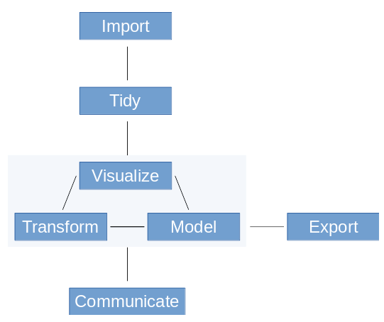

In this workshop, we will cover almost all the different boxes in this chart! Most of our time will be spent on data pre-processing and visualization, both of which are important to learn before using R for statistical analyses and modelling.

#### 2. Questions (eLena chat)

There are many questions and challenges that come up when analyzing a data set. Many of them are likely to come about even before we have started.

Can you think of a question or two concerning the steps above that you might have at this point? It can be a real question you’ve had in mind, or a hypothetical one. It could be practical or purely conceptual. Write down your question in the chat app in eLena (this is also a good time to become familiar with it)!